# DSNDP-Term2

*Term 2 - started on July 23, 2019*

## Overview

Links  
CRISP-DM  
Software Engineering Practices  
Wrtiting Modular Code  
Getting Data Programmatically  
BeautifulSoup  
Unit Tests  
Test-Driven Development and Data Science  
Questions to Ask Yourself When Conducting a Code Review  
Tips for Conducting a Code Review  
Object-Oriented Programming (OOP)  
Making a Package  
Virtual Environments  
Contributing to a GitHub project  
GitHub README Showcase  
PyPI vs Test PyPI  
Portfolio Exercise: Upload a Package to PyPI  
Semantic Versioning  
Web Development  
Bootstrap Library  
Flask  
Deploying your app  
APIs  
REST Architecture  
Medium: Getting Started Posts and Links  
Project Documentation

## Links

[Python Tutorial](https://www.python-course.eu/python3_properties.php)  
[Chris Albon's notes on using Data Science & Machine Learning](https://chrisalbon.com/)  
[Example Google Style Python Docstrings](https://sphinxcontrib-napoleon.readthedocs.io/en/latest/example_google.html)  
[Pandas Styling](https://pandas.pydata.org/pandas-docs/stable/style.html)  
[class methods, instance methods, and static methods](https://realpython.com/instance-class-and-static-methods-demystified/)  
[class attributes vs instance attributes](https://www.python-course.eu/python3_class_and_instance_attributes.php)  
[multiple inheritance, mixins](https://easyaspython.com/mixins-for-fun-and-profit-cb9962760556?gi=d9ed8b47c75f)  
[Python decorators](https://realpython.com/primer-on-python-decorators/)  
[PyPI](https://pypi.org)  
[Test PyPI](https://test.pypi.org)  
Filling missing values | [Pandas](https://pandas.pydata.org/pandas-docs/stable/reference/api/pandas.DataFrame.fillna.html) | [sklearn.preprocessing.library](https://scikit-learn.org/stable/modules/preprocessing.html) |  
[Get a subset of a DataFrame’s columns based on the column dtypes](https://pandas.pydata.org/docs/reference/api/pandas.DataFrame.select_dtypes.html)  
[pandas.get_dummies](https://pandas.pydata.org/pandas-docs/version/0.17.0/generated/pandas.get_dummies.html)

[PEP 484 - Type Hints](https://www.python.org/dev/peps/pep-0484/)  
[PEP 257 - Docstring Conventions](https://www.python.org/dev/peps/pep-0257/)  
[Numpy Docstring Guide](https://numpydoc.readthedocs.io/en/latest/format.html)  
[What makes sets faster than lists?](https://stackoverflow.com/questions/8929284/what-makes-sets-faster-than-lists/8929445#8929445)

[Python String Formatting Best Practices](https://realpython.com/python-string-formatting/)  
Factory (OOP))

**CSS**  
[History of CSS](https://www.w3.org/Style/CSS20/history.html)  
https://www.w3schools.com/cssref/pr_text_text-transform.asp  
[hint: https://www.w3schools.com/css/css_dimension.asp](https://www.w3schools.com/css/css_dimension.asp)  
https://www.w3schools.com/cssref/pr_class_display.asp  
[hint: https://www.w3schools.com/css/css_border.asp](https://www.w3schools.com/css/css_border.asp)

**jQuery**  
https://api.jquery.com/id-selector/  
https://api.jquery.com/click/  
http://api.jquery.com/fadein/

**Bootstrap**  
[Starter Template](https://getbootstrap.com/docs/4.0/getting-started/introduction/#starter-template)  
[Column Grid Explanation](https://getbootstrap.com/docs/4.0/layout/grid/)  
[Containers and Responsive Layout](https://getbootstrap.com/docs/4.0/layout/overview/)  
[Images](https://getbootstrap.com/docs/4.0/content/images/)  
[Navigation](https://getbootstrap.com/docs/4.0/components/navbar/)  
[Font Colors](https://getbootstrap.com/docs/4.0/utilities/colors/)

**Plotly**  
[plotly](https://plot.ly/)  
[javascript examples](https://plot.ly/javascript/)  
[getting started](https://plot.ly/javascript/getting-started/)  
[linking to the plotly library](https://plot.ly/javascript/getting-started/#plotlyjs-cdn)

## CRISP-DM

**Cross-Industry Standard Process for Data Mining**

*has six major phases:*

1. Business Understanding
2. Data Understanding
3. Data Preparation
4. Modeling
5. Evaluation (of results to answer your questions of interest)
6. Deployment (of changes based on the results of your analyses)

## Data Science requires:

- Curiosity
- Data
- Code
- Communication

plus tools:

- Deep Learning
- Machine Learning

## Supervised ML Process:

- Instantiate
- Fit
- Predict
- Score

## Working with Missing Values

*There are three options:*

- Remove
- Impute
- Work Around

#### CRISP-DM

In working with missing values, categorical variables, and building out your model, it was probably easy to lose site of the big picture of the process. Let's take a quick second to recap that here, and pull together the results you should have arrived through your analysis.

1. Business Understanding

How do I break into the field? What are the placement and salaries of those who attended a coding bootcamp? How well can we predict an individual's salary? What aspects correlate well to salary? How well can we predict an individual's job satisfaction? What aspects correlate well to job satisfaction?

1. Data Understanding

Here we used the StackOverflow data to attempt to answer our questions of interest. We did 1. and 2. in tandem in this case, using the data to help us arrive at our questions of interest. This is one of two methods that is common in practice. The second method that is common is to have certain questions you are interested in answering, and then having to collect data related to those questions.

1. Prepare Data

This is commonly denoted as 80% of the process. You saw this especially when attempting to build a model to predict salary, and there was still much more you could have done. From working with missing data to finding a way to work with categorical variables, and we didn't even look for outliers or attempt to find points we were especially poor at predicting. There was ton more we could have done to wrangle the data, but you have to start somewhere, and then you can always iterate.

1. Model Data

We were finally able to model the data, but we had some back and forth with step 3. before we were able to build a model that had okay performance. There still may be changes that could be done to improve the model we have in place. From additional feature engineering to choosing a more advanced modeling technique, we did little to test that other approaches were better within this lesson.

1. Results

Results are the findings from our wrangling and modeling. They are the answers you found to each of the questions.

1. Deploy

Deploying can occur by moving your approach into production or by using your results to persuade others within a company to act on the results. Communication is such an important part of the role of a data scientist.

### Communication of results through Github

Need to have a good README file that has:

- Installations
- Project Motivation
- File Descriptions
- How to Interact with your project
- Licensing
- Authors
- Acknowledgments

# Software Engineering Practices

### Software Engineering Practices Part I

> - Write clean and modular code
> - Improve code efficiency
> - Add effective documentation
> - Use version control
> - Testing
> - Logging
> - Code reviews

**Clean:** code is clean when it is `readable`, `simple`, and `concise`

**Modular:** your code is modular if it is logically broken up into **functions:**

```
def function_name(x,y):
       ...
```

and **modules**:

```
module_name.py
```

**Refactoring:** code refactoring is to improve internal structure without changing external functionality

### Why Refactor?

- Reduce workload in long run
- Easier to maintain code
- Reuse more of your code
- Become a better developer

[PEP 8 guidelines for code layout](https://www.python.org/dev/peps/pep-0008/?#code-lay-out)

### Writing Clean Code

**Tip: Use meaningful names**

> Be descriptive and imply type  
> Be consistent but clearly differentiate  
> Avoid abbrevations and especially single letters (Exception: counters and common math variables)  
> Long names != descriptive names

Example (long names do not always mean good):

```
# bad
def count_unique_values_of_names_list_with_set(names_list):
    return len(set(names_list))


# better
def count_unique_values(arr):
    return len(set(arr))
```

## Writing Modular Code

```python
import math
import numpy as np

def flat_curve(arr, n):
    return [i + n for i in arr]

def square_root_curve(arr):
    return [math.sqrt(i) * 10 for i in arr]

test_scores = [88, 92, 79, 93, 85]
curved_5 = flat_curve(test_scores, 5)
curved_10 = flat_curve(test_scores, 10)
curved_sqrt = square_root_curve(test_scores)

score_kind = ('test_score', 'curved_5', 'curved_10', 'curved_sqrt')
score_list = (test_scores, curved_5, curved_10, curved_sqrt)

# for score_list in test_scores, curved_5, curved_10, curved_sqrt:
for kind, scores in zip(score_kind, score_list):
    print(f"{kind.rjust(11)}: {np.mean(scores)}")
```

```
 test_score: 87.4
   curved_5: 92.4
  curved_10: 97.4
curved_sqrt: 93.44776840374746
```

```python
np.sqrt(90) * 10
```

```
94.86832980505139
```

```python
import matplotlib.pyplot as plt
```

```python
x = range(0,101, 10)
list(x)
```

```
[0, 10, 20, 30, 40, 50, 60, 70, 80, 90, 100]
```

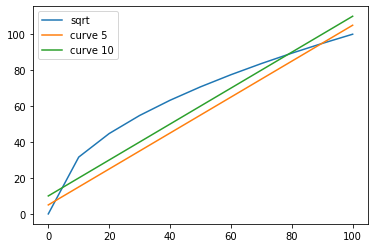

```python
plt.plot(x, square_root_curve(x), label='sqrt')
plt.plot(x, flat_curve(x, 5), label='curve 5')
plt.plot(x, flat_curve(x, 10), label='curve 10')
plt.legend(loc=0);
```

### Efficient Code

- Reducing run time
- Reducing space in memory

## Getting Data Programmatically

```python
url = "https://archive.ics.uci.edu/ml/machine-learning-databases/wine-quality/"

import bs4
import requests
import csv
import pandas as pd
import time

start = time.time()

response = requests.get(url)
soup = bs4.BeautifulSoup(response.text, "html.parser")

# print(soup.prettify())
# print('==============\n')

elements = soup.select("li a")
elements[1].text

for i in range(len(elements)):
    print(elements[i].get('href'))

winequality_red_url = url + (elements[1].text).strip()

res = requests.get(winequality_red_url)
data = res.content

winequality_red = []
is_header=True

for row in data.decode("utf-8").split('\n'):
    if is_header:
        labels=[col.replace(' ', '_').replace('"', '') for col in row.split(';')]
        winequality_red.append(labels)
        is_header=False
    else:
        row = [col.replace(' ', '') for col in row.split(';')]
        winequality_red.append(row)

print(winequality_red[0])
#'''
with open('winequality-red.csv', 'w', newline='') as csvfile:
    wqwriter = csv.writer(csvfile, delimiter=',')
    for row in winequality_red:
        wqwriter.writerow(row)

#'''
print('\nDuration: {:.4f} seconds'.format(time.time() - start))

del winequality_red
```

```
/ml/machine-learning-databases/
winequality-red.csv
winequality-white.csv
winequality.names
['fixed_acidity', 'volatile_acidity', 'citric_acid', 'residual_sugar', 'chlorides', 'free_sulfur_dioxide', 'total_sulfur_dioxide', 'density', 'pH', 'sulphates', 'alcohol', 'quality']

Duration: 1.4462 seconds
```

[output not shown]

## BeautifulSoup

[BeautifulSoup](https://hackersandslackers.com/scraping-urls-with-beautifulsoup/)

```python
df = pd.read_csv('winequality-red.csv')
df.head()
```

|  | fixed_acidity | volatile_acidity | citric_acid | residual_sugar | chlorides | free_sulfur_dioxide | total_sulfur_dioxide | density | pH | sulphates | alcohol | quality |
| --- | --- | --- | --- | --- | --- | --- | --- | --- | --- | --- | --- | --- |
| 0 | 7.4 | 0.70 | 0.00 | 1.9 | 0.076 | 11.0 | 34.0 | 0.9978 | 3.51 | 0.56 | 9.4 | 5.0 |
| 1 | 7.8 | 0.88 | 0.00 | 2.6 | 0.098 | 25.0 | 67.0 | 0.9968 | 3.20 | 0.68 | 9.8 | 5.0 |
| 2 | 7.8 | 0.76 | 0.04 | 2.3 | 0.092 | 15.0 | 54.0 | 0.9970 | 3.26 | 0.65 | 9.8 | 5.0 |
| 3 | 11.2 | 0.28 | 0.56 | 1.9 | 0.075 | 17.0 | 60.0 | 0.9980 | 3.16 | 0.58 | 9.8 | 6.0 |
| 4 | 7.4 | 0.70 | 0.00 | 1.9 | 0.076 | 11.0 | 34.0 | 0.9978 | 3.51 | 0.56 | 9.4 | 5.0 |

```python
df.columns
```

```
Index(['fixed_acidity', 'volatile_acidity', 'citric_acid', 'residual_sugar',
       'chlorides', 'free_sulfur_dioxide', 'total_sulfur_dioxide', 'density',
       'pH', 'sulphates', 'alcohol', 'quality'],
      dtype='object')
```

```python
df.dtypes
```

```
fixed_acidity           float64
volatile_acidity        float64
citric_acid             float64
residual_sugar          float64
chlorides               float64
free_sulfur_dioxide     float64
total_sulfur_dioxide    float64
density                 float64
pH                      float64
sulphates               float64
alcohol                 float64
quality                 float64
dtype: object
```

```python
['Spam'] * 5
```

```
['Spam', 'Spam', 'Spam', 'Spam', 'Spam']
```

```python
import numpy as np

arr = np.array([23, 12, 4, 8, 32, 9, 29, 49, 45, 72])

arr[arr < 25].sum()
```

```
56
```

## Unit Tests

> Test that covers a small unit of code, usually a function independently from the rest of the program  
> [pytest](https://docs.pytest.org)  
> [Integration Testing](https://www.fullstackpython.com/integration-testing.html)

`pip install -U pytest`

#### Unit Testing Tools

To install `pytest`, run `pip install -U pytest` in your terminal. You can see more information on getting started [here](https://docs.pytest.org/en/latest/getting-started.html).

- Create a test file starting with `test_`.
- Define unit test functions that start with `test_` inside the test file.
- Enter `pytest` into your terminal in the directory of your test file and it detects these tests for you.

`test_` is the default; if you wish to change this, you can learn how in this `pytest` [configuration](https://docs.pytest.org/en/latest/explanation/goodpractices.html#test-discovery).

In the test output, periods represent successful unit tests and Fs represent failed unit tests. Since all you see is which test functions failed, it's wise to have only one `assert` statement per test. Otherwise, you won't know exactly how many tests failed or which tests failed.

Your test won't be stopped by failed `assert` statements, but it will stop if you have syntax errors.

```python
def nearest_square(num):
    """ Return the nearest perfect square that is
    lass than or equal to num."""
    root = 0
    while(root + 1) ** 2 <= num:
        root += 1
    return root ** 2, root
```

```python
nearest_square(50)
```

```
(49, 7)
```

```python
nearest_square(277)
```

```
(256, 16)
```

# Test-Driven Development and Data Science

- *Test-driven development:* Writing tests before you write the code that’s being tested. Your test fails at first, and you know you’ve finished implementing a task when the test passes.
- Tests can check for different scenarios and edge cases before you even start to write your function. When start implementing your function, you can run the test to get immediate feedback on whether it works or not as you tweak your function.
- When refactoring or adding to your code, tests help you rest assured that the rest of your code didn't break while you were making those changes. Tests also helps ensure that your function behavior is repeatable, regardless of external parameters such as hardware and time.

Test-driven development for data science is relatively new and is experiencing a lot of experimentation and breakthroughs. You can learn more about it by exploring the following resources.

- [Data Science TDD](https://www.linkedin.com/pulse/data-science-test-driven-development-sam-savage/) | [Agile Data Scientists Do Scale](https://www.linkedin.com/pulse/agile-data-scientists-do-scale-sam-savage)
- [TDD for Data Science](https://tanzu.vmware.com/content/pivotal-engineering-journal)
- [TDD is Essential for Good Data Science Here's Why](https://medium.com/uk-hydrographic-office/test-driven-development-is-essential-for-good-data-science-heres-why-db7975a03a44)
- [Testing Your Code](https://docs.python-guide.org/writing/tests/) (general python TDD)

```python
%%writefile Data_Engineering/Unit_Test2/email_validator.py

# def validate_email(email):
#     if email.count('@') == 1 and email.count('.') == 1:
#         return True
#     return False

import re

pattern = r"^[a-zA-Z0-9.!#$%&'*+/=?^_`{|}~-]+@[a-zA-Z0-9](?:[a-zA-Z0-9-]{0,61}[a-zA-Z0-9])?(?:\.[a-zA-Z0-9](?:[" \
          r"a-zA-Z0-9-]{0,61}[a-zA-Z0-9])?)*$"
regex = re.compile(pattern)


def validate_email(email):
    return regex.match(email) is not None
```

```
Writing Data_Engineering/Unit_Test2/email_validator.py
```

```python
%%writefile Data_Engineering/Unit_Test2/test_email_validator.py
from email_validator import validate_email

def test_validate_email_1():
    assert validate_email('hteju2001@gmail.com')

def test_validate_email_2():
    assert validate_email('andrew@.c@om')

def test_validate_email_3():
    assert validate_email('andrew@.com')

def test_validate_email_4():
    assert validate_email('andrew@udacity.com')

def test_validate_email_5():
    assert validate_email('hteju2001@comcast.net')
```

```
Writing Data_Engineering/Unit_Test2/test_email_validator.py
```

```python
# !pip3 install -U pytest
```

```python
!pytest
```

[output not shown]

```python
import re

pattern = r"^[a-zA-Z0-9.!#$%&'*+/=?^_`{|}~-]+@[a-zA-Z0-9](?:[a-zA-Z0-9-]{0,61}[a-zA-Z0-9])?(?:\.[a-zA-Z0-9](?:[" \
          r"a-zA-Z0-9-]{0,61}[a-zA-Z0-9])?)*$"
regex = re.compile(pattern)
```

```python
regex.match('hteju2001@.com') is not None
```

```
False
```

# Logging

Logging is the process of recording messages to describe events that have occurred while running your software.

Logging is valuable for understanding the events that occur while running your program. For example, if you run your model overnight and the results the following morning are not what you expect, log messages can help you understand more about the context in those results occurred.

### Tips:

- Be professional and clear

  > Bad: Hmmm... this isn't working???  
  > Bad: idk.... :(  
  > Good: Couldn't parse file.
- Be concise and use normal capitalization

  > Bad: Start Product Recommendation Process  
  > Bad: We have completed the steps necessary and will now proceed with the recommendation process for the records in our product database.  
  > Good: Generating product recommendations.
- Choose the appropriate level for logging

  > *Debug*: Use this level for anything that happens in the program. *Error*: Use this level to record any error that occurs. *Info*: Use this level to record all actions that are user driven or system specific, such as regularly scheduled operations.
- Provide any useful information

  > Bad: Failed to read location data  
  > Good: Failed to read location data: store_id 8324971

## Code Reviews

Code reviews benefit everyone in a team to promote best programming practices and prepare code for production.

- [Code reviews](https://github.com/lyst/MakingLyst/tree/master/code-reviews)
- [Code review best practices](https://www.kevinlondon.com/2015/05/05/code-review-best-practices.html)
- Additional References

  > Clean Code book by Robert C. Martin  
  > Regactoring book by Martin Fowler, et. al.  
  > [All the Small Things](https://www.youtube.com/watch?v=8bZh5LMaSmE&list=LLlt4ZSW8NUcXLWiB3NMnK_w&index=2) talk by Sandi Metz  
  > [How to Design a Good API and Why it Matters](https://www.youtube.com/watch?v=aAb7hSCtvGw&list=LLlt4ZSW8NUcXLWiB3NMnK_w&index=49) talk

## Questions to Ask Yourself When Conducting a Code Review

**Is the code clean and modular?**

- Can I understand the code easily?
- Does it use meaningful names and whitespaces?
- Is there duplicated code?
- Can you provide another layer of abstraction?
- Is each function and module necessary?
- Is each function or module too long?

**Is the code efficient?**

- Are there loops or other steps we can vectorize?
- Can we use better data structures to optimize any steps?
- Can we shorten the number of calculations needed for any steps?
- Can we use generators or multiprocessing to optimize any steps?

**Is documentation efficient?**

- Are in-line comments concise and meaningful?
- Is there complex code that's missing documentation?
- Do function use effective docstrings?
- Is the necessary project documentation provided?

**Is the code well tested?**

- Does the code high test coverage?
- Do tests check for interesting cases?
- Are the tests readable?
- Can the tests be made more efficient?

**Is the logging effective?**

- Are log messages clear, concise, and professional?
- Do they include all relevant and useful information?
- Do they use the appropriate logging level?

```python
import pandas as pd

df = pd.DataFrame({'row': ["00000 UNITED STATES", "01000 ALABAMA", "01001 Autauga County, AL",
                           "01003 Baldwin County, AL", "01005 Barbour County, AL"]})

df
```

|  | row |
| --- | --- |
| 0 | 00000 UNITED STATES |
| 1 | 01000 ALABAMA |
| 2 | 01001 Autauga County, AL |
| 3 | 01003 Baldwin County, AL |
| 4 | 01005 Barbour County, AL |

```python
df = pd.DataFrame(df.row.str.split(' ', 1).tolist(), columns=['fips', 'row'])

df
```

|  | fips | row |
| --- | --- | --- |
| 0 | 00000 | UNITED STATES |
| 1 | 01000 | ALABAMA |
| 2 | 01001 | Autauga County, AL |
| 3 | 01003 | Baldwin County, AL |
| 4 | 01005 | Barbour County, AL |

```python
arr = ['braur' '23' 'techFetch' '78943.00' 'h']
```

```python
len(arr)
```

```
1
```

# Tips for conducting a code review

Now that we know what we're looking for, let's go over some tips on how to actually write your code review. When your coworker finishes up some code that they want to merge to the team's code base, they might send it to you for review. You provide feedback and suggestions, and then they may make changes and send it back to you. When you are happy with the code, you approve it and it gets merged to the team's code base.

As you may have noticed, with code reviews you are now dealing with people, not just computers. So it's important to be thoughtful of their ideas and efforts. You are in a team and there will be differences in preferences. The goal of code review isn't to make all code follow your personal preferences, but to ensure it meets a standard of quality for the whole team.

## Tip: Use a code linter

This isn't really a tip for code review, but it can save you lots of time in a code review. Using a Python code linter like [pylint](https://www.pylint.org/) can automatically check for coding standards and PEP 8 guidelines for you. It's also a good idea to agree on a style guide as a team to handle disagreements on code style, whether that's an existing style guide or one you create together incrementally as a team.

## Tip: Explain issues and make suggestions

Rather than commanding people to change their code a specific way because it's better, it will go a long way to explain to them the consequences of the current code and *suggest* changes to improve it. They will be much more receptive to your feedback if they understand your thought process and are accepting recommendations, rather than following commands. They also may have done it a certain way intentionally, and framing it as a suggestion promotes a constructive discussion, rather than opposition.

```
BAD: Make model evaluation code its own module - too repetitive.

BETTER: Make the model evaluation code its own module. This will simplify models.py to be less repetitive and focus primarily on building models.

GOOD: How about we consider making the model evaluation code its own module? This would simplify models.py to only include code for building models. Organizing these evaluations methods into separate functions would also allow us to reuse them with different models without repeating code.
```

## Tip: Keep your comments objective

Try to avoid using the words "I" and "you" in your comments. You want to avoid comments that sound personal to bring the attention of the review to the code and not to themselves.

```
BAD: I wouldn't groupby genre twice like you did here... Just compute it once and use that for your aggregations.

BAD: You create this groupby dataframe twice here. Just compute it once, save it as groupby_genre and then use that to get your average prices and views.

GOOD: Can we group by genre at the beginning of the function and then save that as a groupby object? We could then reference that object to get the average prices and views without computing groupby twice.
```

## Tip: Provide code examples

When providing a code review, you can save the author time and make it easy for them to act on your feedback by writing out your code suggestions. This shows you are willing to spend some extra time to review their code and help them out. It can also just be much quicker for you to demonstrate concepts through code rather than explanations.

Let's say you were reviewing code that included the following lines:

```
first_names = []
last_names = []

for name in enumerate(df.name):
    first, last = name.split(' ')
    first_names.append(first)
    last_names.append(last)

df['first_name'] = first_names
df['last_names'] = last_names
```

BAD: You can do this all in one step by using the pandas str.split method. GOOD: We can actually simplify this step to the line below using the pandas str.split method. Found this on [this stack overflow post](https://stackoverflow.com/questions/14745022/how-to-split-a-column-into-two-columns)

```
df['first_name'], df['last_name'] = df['name'].str.split(' ', 1).str
```

# Object-Oriented Programming (OOP)

### Lesson outline

- Object-oriented programming syntax

  > Procedural vs. object-oriented programming  
  > Classes, objects, methods and attributes  
  > Coding a class  
  > Magic methods  
  > Inheritance
- Using object-oriented programming to make a Python package

  > Making a package  
  > Tour of `scikit-learn` source code  
  > Putting your package on PyPi

### Why object-oriented programming?

Object-oriented programming has a few benefits over procedural programming, which is the programming style you most likely first learned. As you'll see in this lesson:

```
> Object-oriented programming allows you to create large, modular programs that can easily expand over time.
> Object-oriented programs hide the implementation from the end user.
```

Consider Python packages like [Scikit-learn](https://github.com/scikit-learn/scikit-learn), [pandas](https://pandas.pydata.org/), and [NumPy](https://numpy.org/). These are all Python packages built with object-oriented programming. `Scikit-learn`, for example, is a relatively large and complex package built with object-oriented programming. This package has expanded over the years with new functionality and new algorithms.

When you train a machine learning algorithm with `Scikit-learn`, you don't have to know anything about how the algorithms work or how they were coded. You can focus directly on the modeling.

Here's an example taken from the [Scikit-learn website](https://scikit-learn.org/stable/modules/svm.html):

```
from sklearn import svm
X = [[0, 0], [1, 1]]
y = [0, 1]
clf = svm.SVC()
clf.fit(X, y)
```

How does `Scikit-learn` train the SVM model? You don't need to know because the implementation is hidden with object-oriented programming. If the implementation changes, you (as a user of `Scikit-learn`) might not ever find out. Whether or not you *should* understand how SVM works is a different question.

In this lesson, you'll practice the fundamentals of object-oriented programming. By the end of the lesson, you'll have built a Python package using object-oriented programming.

### Lesson files

This lesson uses classroom workspaces that contain all of the files and functionality you need. You can also find the files in the [data scientist nanodegree term 2 GitHub repo](https://github.com/udacity/DSND_Term2/tree/master/lessons/ObjectOrientedProgramming).

## Object-oriented programming (OOP) vocabulary

- *Class*: A blueprint consisting of methods and attributes.
- *Object*: An instance of a class. It can help to think of objects as something in the real world like a yellow pencil, a small dog, or a blue shirt. However, as you'll see later in the lesson, objects can be more abstract.
- *Attribute*: A descriptor or characteristic. Examples would be color, length, size, etc. These attributes can take on specific values like blue, 3 inches, large, etc.
- *Method*: An action that a class or object could take.
- *OOP*: A commonly used abbreviation for object-oriented programming.
- *Encapsulation*: One of the fundamental ideas behind object-oriented programming is called encapsulation: you can combine functions and data all into a single entity. In object-oriented programming, this single entity is called a class. Encapsulation allows you to hide implementation details, much like how the `scikit-learn` package hides the implementation of machine learning algorithms.

In English, you might hear an attribute described as a *property*, *description*, *feature*, *quality*, *trait*, or *characteristic*. All of these are saying the same thing.

Links to more advanced Python OOP topics:

[Class and Instance Attributes](https://www.python-course.eu/python3_class_and_instance_attributes.php)

[Mixins for Fun and Profit](https://easyaspython.com/mixins-for-fun-and-profit-cb9962760556?gi=93c299352ffc)

[Primer on Python Decorators](https://realpython.com/primer-on-python-decorators/)

[Python's Instance Methods, Class Methods, and Static Methods Demystified](https://realpython.com/instance-class-and-static-methods-demystified/)

# Making a Package

> [How to Build Your Very First Python Package](https://www.freecodecamp.org/news/build-your-first-python-package/)  
> [Python - Packages](https://www.tutorialsteacher.com/python/python-package)  
> [Packaging Python Projects](https://packaging.python.org/tutorials/packaging-projects/)  
> [Packaging and distributing projects](https://packaging.python.org/guides/distributing-packages-using-setuptools/)  
> [`setup.py` example](https://github.com/pypa/sampleproject/blob/main/setup.py)  
> [PyPA sample project](https://packaging.python.org/guides/distributing-packages-using-setuptools/)

A Python **module** is just a Python file containing code.

A **package** is a collection of Python modules. A Python package needs an **`__init__.py`** file.

**What is pip?**

`pip` is a [Python package manager](https://pip.pypa.io/en/stable/) that helps with installing and uninstalling Python packages. You might have used pip to install packages using the command line: `pip install numpy`. When you execute a command like `pip install numpy`, `pip` will download the package from a Python package repository called [PyPi](https://pypi.org/) - Python Package Index.

After a package is installed, it can be imported and used in other codes. To see where the package is saved, use the following two lines:

```
import numpy
numpy.__file__
# prints something like this in Windows:
'C:\\Users\\johnny\\Anaconda3\\lib\\site-packages\\numpy\\__init__.py'
```

**Object-Oriented Programming and Python Packages**

A Python package does not need to use object-oriented programming. You could simply have a Python module with a set of functions. However, most - if not all - of the popular Python packages take advantage of object-oriented programming for a few reasons:

1. Object-oriented programs are relatively easy to expand especially because of inheritance
2. Object-oriented programs obscure functionality from the user. Consider `scipy` packages. You don't need to know how the actual code works in order to use its classes and methods.

## Virtual Environments

#### Python Environments

In the next part of the lesson, you'll be given a workspace where you can upload files into a Python package and pip install the package. If you decide to install your package on your local computer, you'll want to create a virtual environment. A virtual environment is a silo-ed Python installation apart from your main Python installation. That way you can install packages and delete the virtual environment without affecting your main Python installation

Let's talk about two different Python environment managers: **conda** and **venv**. You can create virtual environments with either one. Below you'll read about each of these environment managers including some advantages and disadvantages. If you've taken other data science, machine learning or artificial intelligence courses at Udacity, you're probably already familiar with conda.

#### Conda

Conda does two things: **manages packages** and **manages environments.**

As a package manager, conda makes it easy to install Python packages especially for data science. For instance, typing `conda install numpy` will install the numpy package.

As an environment manager, conda allows you to create silo-ed Python installations. With an environment manager, you can install packages on your computer without affecting your main Python installation.

The command line code looks something like this:

```
conda create --name <environmentname>
source activate <environmentname>
conda install numpy
```

#### Pip and Venv

There are other environmental managers and package managers besides conda. For example, **venv** is an environment manager that comes pre-installed with Python 3. **Pip** is a package manager.

Pip can only manage Python packages whereas conda is a language agnostic package manager. In fact, conda was invented because pip could not handle data science packages that depended on libraries outside of Python. If you look at the [history of conda](https://jakevdp.github.io/blog/2016/08/25/conda-myths-and-misconceptions/#Myth-#5:-conda-doesn't-work-with-virtualenv,-so-it's-useless-for-my-workflow), you'll find that the software engineers behind conda needed a way to manage data science packages (NumPy, Matplotlib, etc.) that relied on libraries outside of Python.

Conda manages environments AND packages. Pip only manages packages.

To use venv and pip, the commands look something like this:

```
python3 -m venv environmentname
source environmentname/bin/activate
pip install numpy
```

**Which to Choose**

Whether you choose to create environments with venv or conda will depend on your use case. Conda is very helpful for data science projects, but conda can make generic Python software development a bit more confusing; that's the case for this project.

If you create a conda environment, activate the environment, and then pip install the distributions package, you'll find that the system installs your package globally rather than in your local conda environment. However, if you create the conda environment and install pip simultaneously, you'll find that pip behaves as expected installing packages into your local environment:

```
conda create --name environmentname pip
```

On the other hand, using pip with venv works as expected. Pip and venv tend to be used for generic software development projects including web development. For this lesson on creating packages, you can use conda or venv if you want to develop locally on your computer and install your package.

**Instructions for venv**

For instructions about how to set up virtual environments on a macOS, Linux, or Windows machine using the terminal, see [Installing packages using pip and virtual environments](https://packaging.python.org/guides/installing-using-pip-and-virtual-environments/).

These are a few notes for understanding the tutorial:

- If you are using Python 2.7.9 or later (including Python 3), the Python installation should already come with the Python package manager called pip. There is no need to install it.
- `env` is the name of the environment you want to create. You can call env anything you want.
- Python 3 comes with a virtual environment package pre-installed. So instead of typing `python3 -m virtualenv env`, you can type `python3 -m venv env` to create a virtual environment.

Once you've activated a virtual environment, you can then use terminal commands to go into the directory where your Python library is stored. And then you can run pip install .. In the next section, you can practice pip installing and/or creating virtual environments in the classroom workspace. You'll see that creating a virtual environment actually creates a new folder containing a Python installation. Deleting this folder will remove the virtual environment.

Note that if you install packages on the workspace and run into issues, you can always reset the workspace; however, you will lose all of your work. So be sure to download any files you want to keep before resetting a workspace.

`C:\Users\hailu\Anaconda3\envs\dsndp`

## Contributing to a GitHub project

Here are a few links about how to contribute to a github project:

- [Beginner's Guide to Contributing to a Github Project](https://akrabat.com/the-beginners-guide-to-contributing-to-a-github-project/)
- [Contributing to a Github Project](https://github.com/MarcDiethelm/contributing/blob/master/README.md)

## GitHub README Showcase

Some of the qualities of good **README** files include:

1. Installations
2. Project Motivation
3. File Descriptions
4. How to interact with your project
5. Licensing, authors, acknowledgments, etc.

A full Udacity course on this topic can be found [here](https://classroom.udacity.com/courses/ud777)

Examples of good README are shown here [Bootstrap](https://github.com/twbs/bootstrap) | [Scikit-Learn](https://github.com/scikit-learn/scikit-learn) | [Stack Overflow Blog](https://github.com/jjrunner/stackoverflow)

## PyPI vs. Test PyPI

Note that pypi.org and [test.pypy.org](https://test.pypi.org) are two different websites. You'll need to register separately at each website. If you only register at pypi.org, you will not be able to upload to the [test.pypy.org](https://test.pypi.org) repository.

Also, remember that your package name must be unique. If you use a package name that is already taken, you will get an error when trying to upload the package.

### Terminal Commands

```
cd binomial_package_files
python setup.py sdist
pip install twine

# commands to upload to the pypi test repository
twine upload --repository-url https://test.pypi.org/legacy/ dist/*
#pip install --index-url https://test.pypi.org/simple/ dsndp-distributions
pip install -i https://test.pypi.org/simple/ dsndp-distributions   # install using the test.pypi.org package

# command to upload to the pypi repository
twine upload dist/*
# pip uninstall dsndp_distributions (if was already installed using the test.pypi.org package)
pip install dsndp-distributions   # install using the package in pypi.org
```

### More PyPI Resources

**Tutorial on distributing packages**

This link has a good tutorial on distributing Python packages including more configuration options for your setup.py file: [tutorial on distributing packages](https://packaging.python.org/tutorials/packaging-projects/). You'll notice that the python command to run the setup.py is slightly different with

```
python3 setup.py sdist bdist_wheel
```

This command will still output a folder called `dist`. The difference is that you will get both a .tar.gz file and a .whl file. The .tar.gz file is called a *source archive* whereas the .whl file is a *built distribution.* The .whl file is a newer type of installation file for Python packages. When you pip install a package, pip will first look for a whl file (wheel file) and if there isn't one, will then look for the tar.gz file.

A tar.gz file, ie an sdist, contains the files needed to [compile](https://en.wikipedia.org/wiki/Compiler) and install a Python package. A whl file, ie a *built distribution*, only needs to be copied to the proper place for installation. Behind the scenes, pip installing a whl file has fewer steps than a tar.gz file.

Other than this command, the rest of the steps for uploading to PyPI are the same.

**Other Links**

If you'd like to learn more about PyPI, here are a couple of resouirces:

- [Overview of PyPI](https://docs.python.org/3/distutils/packageindex.html)
- [MIT License](https://opensource.org/licenses/MIT)

## Portfolio Exercise: Upload a Package to PyPI

Personal portfolios are an excellent way to demonstrate your knowledge and creativity. In fact, they are little by little becoming a must-have for people working in the tech industry. In this portfolio building exercise, you will build a Python package and upload the package to PyPi.

#### Getting Started

Next, you'll find a blank classroom workspace where you can do your work. The benefits of using the workspace over your own computer are two fold:

- you shouldn't run into set-up issues
- if you install something on the workspace that causes issues, you can always reset everything

The workspace is the same Ubuntu Linux environment you've been using to do the exercises. You are also welcome to develop your package locally on your own computer if you prefer.

For local development, if you are developing on macOS, you can use the exact same terminal commands. On a windows machine, the commands are slightly different and you'll need to use the command prompt. This link contains a [comparison of MS-DOS vs Linux commands](https://access.redhat.com/documentation/en-US/Red_Hat_Enterprise_Linux/4/html/Step_by_Step_Guide/ap-doslinux.html).

If at some point you decide to reset your workspace, make sure you have saved your work somewhere else like in a GitHub repository; otherwise, all of your work will be deleted. You can connect to a remote GitHub repo from within the workspace terminal. Here is a reminder of how to do that: [adding an existing repository to GitHub using the command line](https://help.github.com/en/articles/adding-an-existing-project-to-github-using-the-command-line). Another option is to download files or folders directly from the workspace. You right click on the file/folder name and click "Download".

In the workspace, you'll see that the files and folders have already been set up for you in terms of the structure, but the files themselves are empty.

Every time you type in the workspace, your work is automatically saved. But you should still save and commit your work to GitHub as well.

#### Instructions

Build a Python package and upload the package to PyPi. We encourage you to use object-oriented programming and tackle a problem that interests you. The Introduction to Object-Oriented Programming lesson has all of the information needed to create a package and upload the package. As mentioned in the lesson material, you'll need to use a unique name to upload the package to PyPi since each package needs a unique name; hence 'dsnd-probability' will not work since that package name is already taken.

Here are a few ideas for packages:

- create a package that does basic matrix algebra such as addition, subtraction, multiplication, matrix inversion, etc.
- make a calculus package that implements algorithms such as Newton's method
- create a package built on top of Matplotlib or Seaborn that creates well-formatted, well labeled visualizations
- create an object-oriented package to play a game of tic-tac-toe between two human players.
- or make a number guessing game where the computer randomly chooses an integer and then tells a human player if a guess is higher or lower than the number

Feel free to come up with your own ideas. The main goal is to develop and demonstrate your skills in object-oriented programming and uploading packages to PyPi.

#### Reminders

- include a README file detailing the files in your package and how to install the package.
- Comment your code - use docstrings and inline comments where appropriate.
- Refactor code when possible - if you find your functions are getting too long, then refactor your code!
- Use object-oriented programming whenever it makes sense to do so.
- You're encouraged to write unit tests! The coding exercises in this lesson contained unit tests, so you can use those tests as a model for your package.
- Use GitHub for version control, and commit your work often.

As a reminder, your package should be placed in a folder with the following folders and files:

- a folder with the name of your package that contains:
  - the Python code that makes up your package
  - a `README.md` file
  - an `__init__.py`
  - `license.txt`
  - `setup.cfg`
- `setup.py` file

#### Hints and Helpful Links

Because this exercise requires writing and organizing code in a specific way, you might have to rewatch some of the lecture videos especially the "Putting Code on PyPi" concept.

Before you upload your code to PyPi, you should first pip install the package locally to make sure everything works as expected. The "Making a Package" and "Virtual Environments" lesson concepts should be helpful. You should also consider writing unit tests to test the functionality of your package. In the object-oriented programming lesson workspace, there were unit tests inside the 4a_binomial_package folder that you can use to help you get started. Those were in a file called test.py.

The object-oriented programming lesson included a complete, working package called dsnd-probability. We encourage you to code a project from scratch; however, if you get stuck, use the dsnd-probability package code as a template. It already contains all of the necessary files you'll need for creating a package. It's also a simple example of object-oriented code. You can use these files, including the setup.py and setup.cfg files, to help structure your own code.

Those files are located in the "Exercise: Upload to PyPi" section inside the "5_exercise_upload_to_pypi" folder.

Besides the lesson on object-oriented programming, you might find [this package building summary guide from the Python website](https://packaging.python.org/guides/distributing-packages-using-setuptools/) helpful.

For a much more detailed explanation of distributing Python packages, check out the documentation on Distutils.

- Introduction
- setup.py script
- config file
- source distributions
- built distributions
- uploading to PyPi

#### Uploading to PyPi

When you are ready to upload your package, you can first upload to the [PyPi test repository](https://test.pypi.org). Once everything is working as expected, you can upload to the public facing [PyPi repository](https://pypi.org).

As a reminder, you'll need to create a username for both the test and public facing repositories. You'll also need to pip install the twine package with: `pip install twine`. You can rewatch the lesson videos to see how to upload your package.

Continue on to the next sections to get some troubleshooting tips, and access the project workspace. When you're finished with your project, show off your work on a personal website, GitHub, and LinkedIn.

## Troubleshooting Possible Errors

#### PyPI vs. Test PyPI

Note that pypi.org and test.pypi.org are two different websites. You'll need to register separately at each website. If you only register at pypi.org, you will not be able to upload to the test.pypi.org repository.

#### Uniquer Name

Remember that your package name must be unique. If you use a package name that is already taken, you will get an error when trying to upload the package.

#### Re-uploading and Versioning

Once you upload your package to PyPI, you cannot upload the same version again. All that means is that you need to go into your `setup.py` file and change the version number. For example, if you uploaded a package with `version = 0.1.1`, then you'll need to change this to something else like `version = 0.1.2`.

If you've ever wondered what all these version numbers mean, here is a tutorial about [semantic versioning](https://semver.org/). Semantic versioning is a standard for deciding when to move up to the next number in your versioning scheme.

#### [Semeantic Versioning 2.0.0 - Summary](https://semver.org/)

Given a version number MAJOR.MINOR.PATCH, increment the:

1. MAJOR version when you make incompatible API changes,
2. MINOR version when you add functionality in a backward compatible manner, and
3. PATCH version when you make backward compatible bug fixes.

Additional labels for pre-released and build metadata are available as extensions to the MAJOR.MINOR.PATCH format

# Web Development

**How to Think about This Lesson**

The lesson first gives an overview of the three base languages for web development: html, css, and JavaScript. You could take an entire course just on each of these languages. The goal is for you to get comfortable writing at least some code in each language so that you understand the web template files at the end of the lesson. This lesson goes through a lot of information to get you up to speed.

To work with the web template and make a data dashboard, you will only need to write Python code. If you want to customize the dashboard, you can do so with just a few changes to the html code. But the underlying technologies of data dashboard will be css, html, JavaScript, and Python.

**Lesson Outline**

- Basics of a web app

  > [HTML](https://www.w3schools.com/html/)  
  > [CSS](https://www.w3schools.com/w3css/)  
  > [JavaScript](https://www.w3schools.com/js/default.asp)  
  > [jQuery](https://www.w3schools.com/Jquery/default.asp)
- Front-end libraries

  > [boostrap](https://getbootstrap.com/)  
  > plotly
- Back-end libraries

  > flask
- Deploy a web app to the cloud

**Lesson Files**

All of the lesson's exercises are contained in classroom workspaces. You'll even deploy a web app from the classroom workspace; however, if you prefer to work locally, you can find the lesson files in [this data scientist nanodegree GitHub repo](https://github.com/udacity/DSND_Term2/tree/master/lessons/WebDevelopment).

### HTML Validator

[HTML Validator](https://validator.w3.org/#validate_by_input)

### CSS related links

> [History of CSS](https://www.w3.org/Style/CSS20/history.html)  
> [css text-transform](https://www.w3schools.com/cssref/pr_text_text-transform.asp)  
> [css dimension](https://www.w3schools.com/css/css_dimension.asp)  
> [css display](https://www.w3schools.com/cssref/pr_class_display.asp)  
> [css font-family](https://www.w3schools.com/cssref/pr_font_font-family.asp)  
> [css border](https://www.w3schools.com/css/css_border.asp)

### JavaScript

**JavaScript and this Lesson**

To build the data dashboard at the end of this lesson, you won't need to write any JavaScript at all. That's because you'll use libraries ([Bootstrap](https://getbootstrap.com/) and [Plotly](https://plotly.com/)) that take care of the JavaScript for you.

You won't need to get into the details of JavaScript syntax, but it's good to have at least an idea of what is happening under the hood.

**What is JavaScript?**

- JavaScript is a high level language like Python, PHP, Ruby, and C++. It was specifically developed to make the front-end of a web application more dynamic; however, you can also use javascript to program the back-end of a website with the JavaScript runtime environment [node](https://nodejs.org/en/).
- Java and javaScript are two completely different languages that happen to have similar names.
- JavaScript syntax, especially for front-end web development, is a bit tricky. It's much easier to write front-end JavaScript code using a framework such as [jQuery](https://api.jquery.com/).

**Basic JavaScript Syntax**

Here are a few rules to keep in mind when writing JavaScript:

- a line of code ends with a semi-colon ;
- () parenthesis are used when calling a function much like in Python
- {} curly braces surround large chunks of code or are used when initializing dictionaries
- [] square brackets are used for accessing values from arrays or dictionaries much like in Python

Here is an example of a JavaScript function that sums the elements of an array.

```
function addValues(x) {
  var sum_array = 0;
  for (var i=0; i < x.length; i++) {
    sum_array += x[i];
  }
  return sum_array;
}

addValues([3,4,5,6]);
```

**What is jQuery?**

Jquery is a JavaScript library that makes developing the front-end easier. JavaScript specifically helps with manipulating html elements. The reason we are showing you Jquery is because the Bootstrap library you'll be using depends on Jquery. But you won't need to write any Jquery yourself.

Here is a link to the documentation of the core functions in jquery: [jQuery API documentation](https://api.jquery.com/)

Jquery came out in 2006. There are newer JavaScript tools out there like [React](https://reactjs.org/) and [Angular](https://angularjs.org/).

As a data scientist, you probably won't need to use any of these tools. But if you work in a startup environment, you'll most likely hear front-end engineers talking about these tools.

**jQuery Syntax**

The jQuery library simplifies JavaScript quite a bit. Compare the syntax. Compare these two examples from the video for changing the h1 title element when clicking on the image.

This is pure JavaScript code for changing the words in the h1 title element.

```
function headFunction() {
    document.getElementsByTagName("h1")[0].innerHTML =
          "A Photo of a Breathtaking View";
}
```

This code searches the html document for all h1 tags, grabs the first h1 tag in the array of h1 tags, and then changes the html. Note that the above code is only the function. You'd also have to add an `onClick` action in the image html tag like so:

```
<img src="image.jpg" onclick="headFunction()">
```

The jQuery code is more intuitive. Once the document has loaded, the following code adds an onclick event to the image. Once the image is clicked, the h1 tag's text is changed.

```
$(document).ready(function(){
    $("img").click(function(){
        $("h1").text("A Photo of a Breathtaking View");
    });
});
```

The dollar sign `$` is jQuery syntax that says "grab this element, class or id". That part of the syntax should remind you somewhat of CSS. For example `$("p#first")` means find the paragraph with `id="first"`. Or `$("#first")` would work as well.

Javascript has something called **callback function**, which can make learning javascript a bit tricky. Callback functions are essentially functions that can be inputs into other functions. In the above code, there is the `ready()` function that waits for the html document to load. Then there is another function being passed into the ready function. This section function adds an **on-click event** to an image tag. Then there's another function passed into the `click()` function, which changes the h1 text.

```
$(document).ready(function () {
    $('#fade_in_tasks').click(function() {
        $('ul').fadeIn();
        $('ul').css('background', 'lightyellow');
        $('table').css('background', 'lightpink');
        $('h1').css('color', 'red');
        $('a#main-link').css('background', 'lightblue');
    });
});
```

https://api.jquery.com/id-selector/  
https://api.jquery.com/click/  
http://api.jquery.com/fadein/

# Bootstrap Library

**Documentation References**

Here are some key parts of the Bootstrap documentation for your reference:

- [Starter Template](https://getbootstrap.com/docs/4.0/getting-started/introduction/#starter-template)
- [Column Grid Explanation](https://getbootstrap.com/docs/4.0/layout/grid/)
- [Containers and Responsive Layout](https://getbootstrap.com/docs/4.0/layout/overview/)
- [Images](https://getbootstrap.com/docs/4.0/content/images/)
- [Navigation Bars](https://getbootstrap.com/docs/4.0/components/navbar/)
- [Font Colors](https://getbootstrap.com/docs/4.0/utilities/colors/)

**Why Bootstrap?**

Bootstrap is one of the easier front-end frameworks to work with. Bootstrap eliminates the need to write CSS or JavaScript. Instead, you can style your websites with HTML. You'll be able to design sleek, modern looking websites more quickly than if you were coding the CSS and JavaScript directly.

# Plotly

**Chart Libraries**

There are many web chart libraries out there for all types of use cases. When choosing a library, you should consider checking whether or not the library is still being actively developed.

[d3.js](https://d3js.org/) is one of the most popular (and complex!) javascript data visualization libraries. This library is still actively being developed, which you can tell because the latest commit to the [d3 GitHub repository](https://github.com/d3/d3) is fairly recent.

Other options include chart.js, [Google Charts](https://developers.google.com/chart/), and [nvd3.js](https://nvd3.org/), which is built on top of d3.js

**Why Plotly**

For this lesson, we've chosen [plotly](https://plotly.com/) for a specific reason: Plotly, although a private company, provides open source libraries for both JavaScript and Python.

Because the web app you're developing will have a Python back-end, you can use the Python library to create your charts. Rather than having you learn more JavaScript syntax, you can use the Python syntax that you already know. However, you haven't built a back-end yet, so for now, you'll see the basics of how Plotly works using the JavaScript library. The syntax between the Python and Javascript versions is similar.

Later in the lesson, you'll switch to the Python version of the Plotly library so that you can prepare visualizations on the back-end of your web app. Yet you could write all the visualization code in JavaScript if you wanted to. Watch the screencast below to learn the basics of how Plotly works, and then continue on to the Plotly exercise.

Here are a few links to some helpful parts of the plotly documentation:

- [Plotly JavaScript Examples](https://plotly.com/javascript/)
- [Getting Started in JavaScript](https://plotly.com/javascript/getting-started/)
- [linking to the plotly library](https://plotly.com/javascript/getting-started/#plotlyjs-cdn)

# The Backend

**Using Flask in the Classroom Workspace**

In the next part of the lesson, you'll see a classroom workspace. The classroom workspace already has Flask set up for you. So for now, all you need to do to run the Flask app is to open a Terminal and type.

```
python worldbank.py
```

That assumes you are in the default workspace directory within Terminal. That will get the server running.

**Seeing your App in the Workspace**

Once the server is running, open a new terminal window and type

```
env | grep WORK
```

This command will return the Linux environmental variables that contain information about your classroom workspace. The env command will list all the environmental variables. The | symbol is a pipe for sending output from one command to another. The grep command searches text, so grep WORK will search for any text containing the word WORK.

The command should return two variables:

```
WORKSPACEDOMAIN=udacity-student-workspaces.com
WORKSPACEID=viewc7f399f2
```

Your WORKSPACEID variable will be different but the WORKSPACEDOMAIN should be the same. Now, open a new web browser window, and type the following in the address bar:

```
http://WORKSPACEID-3001.WORKSPACEDOMAIN
```

In this example, that would be: https://viewc7f399f2-3001.udacity-student-workspaces.com/

DON'T FORGET TO INCLUDE -3001. You should be able to see the web app. The number 3001 represents the port for accessing your web app.

## Flask

### Creating New Pages

To create a new web page, you first need to specify the route in the routes.py as well as the name of the html template.

```
@app.route('/new-route')
def render_the_route():
    return render_template('new_route.html')
```

The route name, function name, and template name do not have to match; however, it's good practice to make them similar so that the code is easier to follow.

The new_route.html file must go in the templates folder. Flask automatically looks for html files in the templates folder.

### What is @app.route?

To use Flask, you don't necessarily need to know what @app.route is doing. You only have to remember that the path you place inside of @app.route() will be the web address. And then the function you write below @app.route is used to render the correct html template file for the web address.

In Python, the @ symbol is used for **decorators**. Decorators are a shorthand way to input a function into another function. Take a look at this code. Python allows you to use a function as an input to another function:

```
def decorator(input_function):

    return input_function

def input_function():
    print("I am an input function")

decorator_example = decorator(input_function)
decorator_example()
```

Running this code will print the string:

*I am an input function*

Decorators provide a short-hand way of getting the same behavior:

```
def decorator(input_function):
    print("Decorator function")
    return input_function

@decorator
def input_function():
    print("I am an input function")

input_function()
```

This code will print out:

*Decorator function* *I am an input function*

Instead of using a decorator function, you could get the same behavior with the following code:

```
input_function = decorator(input_function)
input_function()
```

Because `@app.route()` has the `.` symbol, there's an implication that app is a class (or an instance of a class) and route is a method of that class. Hence a function written underneath `@app.route()` is going to get passed into the route method. The purpose of `@app.route()` is to make sure the correct web address gets associated with the correct html template. This code

```
@app.route('/homepage')
def some_function()
  return render_template('index.html')
```

is ensuring that the web address 'www.website.com/homepage' is associated with the index.html template.

If you'd like to know more details about decorators and how @app.route() works, check out these tutorials:

- [how @app.route works](https://ains.co/blog/things-which-arent-magic-flask-part-1.html)
- [general decorators tutorial](https://realpython.com/primer-on-python-decorators/)

## Beyond a CSV file

Besides storing data in a local csv file (or text, json, etc.), you could also store the data in a database such as a SQL database.

The database could be local to your website meaning that the database file is stored on the same server as your website; alternatively, the database could be stored somewhere else like on a separate database server or with a cloud service like Amazon AWS.

Using a database with your web app goes beyond the scope of this introduction to web development, here are a few resources for using databases with Flask apps:

- [Tutorial - Using Databases with Flask](https://blog.miguelgrinberg.com/post/the-flask-mega-tutorial-part-iv-database)
- [SQL Alchemy](https://docs.sqlalchemy.org/en/13/)- a Python toolkit for working with SQL
- [Flask SQLAlchemy](https://flask-sqlalchemy.palletsprojects.com/en/2.x/) - a Flask library for using SQLAlchemy with Flask

```python
keepcolumns = [str(x) for x in range(1995, 2000)]
```

```python
keepcolumns
```

```
['1995', '1996', '1997', '1998', '1999']
```

```python
keepcolumns.insert(0, 'Country Name')
```

```python
keepcolumns
```

```
['Country Name', '1995', '1996', '1997', '1998', '1999']
```

## Deploying your app

### Instructions Deploying from the Classroom

Here is the code used in the screencast to get the web app running:

1. Create a new folder *web_app*, and move all of the application folders and files to the new folder:

```
cd 5_deployment/
mkdir web_app
mv -t web_app/ data/ worldbankapp/ worldbank.py  wrangling_scripts/ requirements.txt runtime.txt
```

1. Create a virtual environment and then activate the environment:

```
# Update Python
conda update python
# Run the following from the Exercise folder
# Create a virtual environment
python3 -m venv worldbankvenv
# Activate the new environment (Mac/Linux)
source worldbankenv/bin/activate
```

The new environment will automatically come with Python packages meant for data science. In addition, pip install the specific Python packages needed for the web app

```
pip install flask==0.12.5 pandas==0.23.3 plotly==2.0.15 gunicorn==19.10.0
```

1. Install the Heroku command-line tools. The classroom workspace already has Heroku installed.

```
# Verify the installation
heroku --version
heroku update #(using git-bash to update it to the latest version if necessary)
# Install, if Heroku not present
curl https://cli-assets.heroku.com/install-ubuntu.sh | sh
```

For your local installation, you can refer to the [official installation instructions](https://devcenter.heroku.com/articles/heroku-cli#standalone-installation). And then log into heroku with the following command

```
heroku login -i
```

Heroku asks for your account email address and password, which you type into the terminal and press enter.

1. The next steps involves some housekeeping:
- remove `app.run()` from `worldbank.py`
- type `cd web_app` into the Terminal so that you are inside the folder with your web app code.

Create a proc file, which tells Heroku what to do when starting your web app:

```
touch Procfile
```

Then open the Procfile and type:

```
web gunicorn worldbank:app
```

1. Create a *requirements.txt* file, which lists all of the Python packages that your app depends on:

```
pip freeze > requirements.txt
```

For workspace users, the *requirements.txt* is already available in the exercise folder. In addition, we have also provided a *runtime.txt* file in the exercise folder, that declares the exact Python version number to use. Heroku supports [these](https://devcenter.heroku.com/articles/python-support#supported-runtimes) Python runtimes.

1. Initialize a git repository and make a commit:

```
# Run it just once, in the beginning
git init
# For the first time commit, you need to configure the git username and email:
git config --global user.email "you@example.com"
git config --global user.name "Your Name"
```

Whenever you make any changes to your *web_app* folder contents, you will have to run `git add` and `git commit` commands.

```
# Every time you make any edits to any file in the web_app folder
git add .
# Check which files are ready to be committed
git status
git commit -m "your message"
```

1. Now, create a Heroku app:

```
heroku create my-app-name --buildpack heroku/python
# For example,
# heroku create sudkul-web-app --buildpack heroku/python
# The output will be like:
# https://sudkul-web-app.herokuapp.com/ | https://git.heroku.com/sudkul-web-app.git
```

where my-app-name is a unique name that nobody else on Heroku has already used. You can optionally define the build environment using the option `--buildpack heroku/python` The `heroku create` command should create a git repository on Heroku and a web address for accessing your web app. You can check that a remote repository was added to your git repository with the following terminal command:

```
git remote -v
```

1. Before you finally push your local git repository to the remote Heroku repository, you will need the following environment variables (kind of secrets) to send along:

```
# Set any environment variable to pass along with the push
heroku config:set SLUGIFY_USES_TEXT_UNIDECODE=yes
heroku config:set AIRFLOW_GPL_UNIDECODE=yes
# Verify the variables
heroku config
```

If your code uses any confidential variable value, you can use this approach to send those values secretly. These values will not be visible to the public users. Now, push your local repo to the remote Heroku repo:

```
# Syntax
# git push <remote branch name> <local branch name>
git push heroku master
```

Other useful commands are:

```
# Clear the build cache
heroku plugins:install heroku-builds
heroku builds:cache:purge -a <app-name> --confirm <app-name>
# Permanently delete the app
heroku apps:destroy  <app-name> --confirm <app-name>
```

Now, you can type your web app's address, such as https://sudkul-web-app.herokuapp.com/, in the browser to see the results.

**Other Services Besides Heroku**

Heroku is just one option of many for deploying a web app, and Heroku is actually owned by [Salesforce.com](https://www.salesforce.com/).

The big internet companies offer similar services like [Amazon's Lightsail](https://aws.amazon.com/lightsail/), [Microsoft's Azure](https://docs.microsoft.com/en-us/samples/azure-samples/python-docs-hello-world/python-flask-sample-for-azure-app-service-linux/), [Google Cloud](https://cloud.google.com/appengine/docs/standard/python/setting-up-environment), and [IBM Cloud (formerly IBM Bluemix)](https://www.ibm.com/cloud/blog). However, these services tend to require more configuration. Most of these also come with either a free tier or a limited free tier that expires after a certain amount of time.

**Virtual Environments vs. Anaconda**

Virtual environments and Anaconda serve a very similar purpose.

- Anaconda is a distribution of Python (and the analytics language R) specifically for data science. Anaconda comes installed with a package and **environment manager** called conda.
- To ensure that your app only installs necessary packages, you should create a **virtual Python environment**. A virtual Python environment is a separate Python installation on your computer that you can easily remove and won't interfere with your main Python installation. You can create [separate environments using conda](https://conda.io/projects/conda/en/latest/user-guide/tasks/manage-environments.html). These environments automatically come with default Python packages meant for data science. However, there can be additional packages that you'd want to install in the new environment.

When deploying a web app to a server, you should only include the necessary packages for running your web app. Otherwise, you'd be installing Python packages that you don't need. We have already provided the package list in the requirements.txt in the workspace above. However, you can create one yourself using the `pip freeze > requirements.txt` command from the new environment.

**Creating a Virtual Environment Locally on Your Computer**

You can develop your app using the classroom workspace. If you decide to develop your app locally on your computer, you should set up a virtual environment there as well. Different versions of Python have different ways of setting up virtual environments. The env command allows us to create lightweight virtual environments :

```
# Optional - Update Python installation
conda update python
# Create a virtual environment
python3 -m venv myenv
# Activate the new environment
source myenv/bin/activate
# The new environment will automatically come with Python packages meant for data science.
```

On Windows, the command is;

```
> py -3 -m venv myvenv
> myvenv\Scripts\activate.bat
```

For more information, read through this [link](https://docs.python.org/3/tutorial/venv.html).

**Databases for Your App**

The web app in this lesson does not need a database. All of the data is stored in CSV files; however, it is possible to include a database as part of a Flask app. One common use case would be to store user login information such as username and password.

Flask is database agnostic meaning Flask can work with a number of different database types. If you are interested in learning about how to include a database as part of a Flask app, here are some resources:

- [Flask Mega Tutorial](https://blog.miguelgrinberg.com/post/the-flask-mega-tutorial-part-iv-database)
- [Heroku - Provision a Database](https://devcenter.heroku.com/articles/getting-started-with-python#provision-a-database)

**Deployment**

In the next part of the lesson, you'll find a workspace where you can practice deploying the world bank web app. Set up an account on [Heroku](https://www.heroku.com/) and then follow the instructions shown in this part of the lesson.

You'll need to use a different name for the web app since the one used in this lesson is already taken.

Supporting Materials

- requirements.txt
- runtime.txt

## What is an API?

Instead of downloading World Bank data via a csv file, you're going to download the data using the World Bank API.

API is an acronym that stands for application programming interface. API’s provide a standardized way for two applications to talk to each other. For this project, the applications communicating with each other are the server application where World Bank stores data and your web application.

If you wanted to pull data directly from the World Bank’s server, you’d have to know what database system the World Bank was using. You’d also need permission to log in directly to the server, which would be a security risk for the World Bank. And if the World Bank ever migrated its data to a new system, you would have to rewrite all of your code again.

The API sits between your web app and the World Bank server. And the API allows you to execute code on the World Bank server without getting direct access.

All sorts of companies have public facing APIs including Facebook, Twitter, Google and Pinterest. You can pull data from these companies to create your own applications.

In the next section, you’ll get practice using Python to pull data from the World Bank API. This will set you up for creating the web app with data from the API instead of using data from a csv file.

### APIs Besides the World Bank

All types of companies have APIs. Some of these APIs are only for internal company use while other APIs help the public consume data. A few examples of public APIs include the [Twitter API](https://developer.twitter.com/en/docs), the [Google Maps API](https://cloud.google.com/maps-platform/), the [Facebook Graph API](https://developers.facebook.com/docs/graph-api), and the [US Government Data APIs](https://www.data.gov/developers/apis).

In addition, oftentimes you can find open source libraries or development kits for connecting to an API. For example, [here](https://github.com/mobolic/facebook-sdk) is an open source Python development kit for the Facebook Graph API.

Some APIs might be used for pulling data from a database. But other APIs are for adding data to a database. For example, you might make an application that automatically tweets the current weather. In that case, you would use the Twitter API to post a tweet, which in reality inserts a tweet into Twitter's database.

### Using an API

In the next few parts of the lesson, you'll see how to use the World Bank API. This API is relatively straightforward to use. Each API, however, will have a different set up and only allow you to take certain actions. In general, you send a request via a web url that specifies the information you want. You receive data back typically in [XML](https://www.w3schools.com/xml/xml_whatis.asp) or [JSON](https://www.w3schools.com/js/js_json_intro.asp).

Some APIs require authentication; essentially the company with the API gives you 'credentials' so that they can track how you are using the API and ensure you have the proper permissions.

Some APIs might let you extract data from a database. Other APIs might even let you insert data into a database depending on the use case. Most APIs include extensive documentation so that you can figure out how to use APIs.

If you ever can’t figure out how to use an API, search online for examples. You can search for something like, “Examples for using the World Bank API” or “Examples for using the Facebook API”.

Move on to the next section to see how to use the World Bank API and incorporate it into a web app.

## REST Architecture

REST is a software architecture for the web. You don't need to understand how REST works in order to use an API. but you will see the term used quite frequently when working with APIs. Modern web APIs are often called RESTFul to indicate that they conform to a REST Architecture.

- [REST API Tutorial](https://restfulapi.net/)
- [Wikipedia Article on REST](https://en.wikipedia.org/wiki/Representational_state_transfer)

### World Bank API

Here is the website where the csv files were downloaded for the World Bank web app: [World Bank Indicator Data](https://data.worldbank.org/indicator?tab=featured)

And here is the link to the World Bank API documenation: [World Bank API Documentation](https://datahelpdesk.worldbank.org/knowledgebase/articles/889392-api-documentation)

One tricky aspect of working with the World Bank API is that it only gives back 50 results at a time. There is an option called per_page that allows you to return up to 1000 results. However, some queries might have more than 1000 results. That's where the `page` option comes into play. You'll notice that at the very beginning of the data, there is a variable called `page` and another one called `pages`. If page=1 and pages=4, then you'd need to write 4 queries with the option page=1, page=2, page=3 and page=4.

Next, you'll practice pulling data from the API using Python code.

# Using APIs with Python

This Ipython notebook shows you how to use the World Bank API with the Python requests library. At the end there is a short exercise for you.

To access APIs in Python, you can use the [requests library](http://docs.python-requests.org/en/master/user/install/).

To install, you can go in a terminal and type:

```
pip install pipenv
pipenv install requests
```

When you use the requests library, it's like putting an API url in a browser except now Python does this behind the scenes programatically and then stores the results in a variable. The classroom workspaces already have the requests library installed. Here is a demonstration of how the request library works.

# Explanation of Results

```
import requests
```

This line imports the requests library.

```
r = requests.get('http://api.worldbank.org/v2/countries/br/indicators/NY.GDP.MKTP.CD')
```

The line `requests.get` sends out a "get" request to the url specified in parenthesis. The html standard specifies different types of [request methods](https://developer.mozilla.org/en-US/docs/Web/HTTP/Methods) with the most common one being "get". A "get" request is generally reserved for obtaining data from a server. For the World Bank API, you'll only need to make "get" requests. An API's documentation will generally tell you what type of requests to make.

The last line of code outputs the results.

```
r.text
```

In this case, the output is xml data. [XML](https://www.w3schools.com/xml/xml_whatis.asp) is a language for storing and transmitting data. XML was standardized in the late 1990s. A few years later, the JSON format came along and serves a similar purpose. JSON tends to be much easier to work with and luckily, the World Bank API can return data in json format by specifying the format parameters.

Next, you'll see how to send parameters with your get request.

# Sending Parameters with the Get Request

This url, `http://api.worldbank.org/v2/countries/br/indicators/NY.GDP.MKTP.CD`, obtains GDP data for Brazil. You specify the country name with the [2-character ISO code](http://www.nationsonline.org/oneworld/country_code_list.htm) and then specify the economic indicator that you want, which in this case is `NY.GDP.MKTP.CD`.

To see all of the possible indicators, visit the [world bank indicator dashboard](https://data.worldbank.org/indicator?tab=all) or use the API address `http://api.worldbank.org/v2/indicators`.

The url syntax is specific to the World Bank API. Other APIs might be different.

When making a get request, you can add parameters to the end of the url with the following syntax: `http://api.worldbank.org/v2/countries/br/indicators/NY.GDP.MKTP.CD?format=json&per_page=500&date=1990:2015`

where a question mark was added at the end of the url following by each parameter name and parameter values. The parameters are separated by the ampersand & sign. Adding parameters to a get request with the question mark ? and ampersand is the standard way for adding parameters to a get request.

With the requests library, you can send this get request in one of two ways. The first way specifies the entire url in a single string.

```
r = requests.get('http://api.worldbank.org/v2/countries/br/indicators/NY.GDP.MKTP.CD?format=json&per_page=500&date=1990:2015')
```

The second way separate the base url and the parameters.

```
payload = {'format': 'json', 'per_page': '500', 'date':'1990:2015'}
r = requests.get('http://api.worldbank.org/v2/countries/br/indicators/NY.GDP.MKTP.CD', params=payload)
```

Why use the second version? It's somewhat easier to write programs with the second version because you can easily change the values in the payload dictionary whereas the first version involves manipulating the url string.

Run the code cell below to show that both versions give the same results.

```
all_indicators_url = 'http://api.worldbank.org/v2/indicators'

page_content = requests.get(all_indicators_url).text
soup = BeautifulSoup(response.text, 'lxml')

soup.find("wb:indicator")



r_url = requests.get('http://api.worldbank.org/v2/countries/br/indicators/NY.GDP.MKTP.CD?format=json&per_page=500&date=1990:2015')

payload = {'format': 'json', 'per_page': '500', 'date':'1990:2015'}
r_payload = requests.get('http://api.worldbank.org/v2/countries/br/indicators/NY.GDP.MKTP.CD', params=payload)

# Test if both results are the same string
assert r_url.text == r_payload.text
```

# Navigating the JSON response

Once you have the data, what can you do with it? The requests library comes with a json decoder. In order to obtain the json response, all you have to do is use the .json() method like so:

```
payload = {'format': 'json', 'per_page': '500', 'date':'1990:2015'}
r = requests.get('http://api.worldbank.org/v2/countries/br/indicators/NY.GDP.MKTP.CD', params=payload)
r.json()
```

Run the cell below to see the results:

```
url = 'http://api.worldbank.org/v2/countries/br/indicators/NY.GDP.MKTP.CD'
payload = {'format': 'json', 'per_page': '500', 'date':'1990:2015'}

r = requests.get(url, params=payload).json()
```

The result is a list of json values, which you can iterate through to access all of the data. Every API will return data in a slightly different way, so you need to look at the data and figure out how to clean the data for your purposes. For example, in the json response, the first entry contains meta data about the results. The second entry is a list containing all of the data points. For the purposes of analyzing the data, you only need the second entry, which you can access with `r.json()[1]`. Run the code cells below to see an example of how to iterate through the data, clean the data, and then plot the results.

```
# get the World Bank GDP data for Brazil, China and the United States
payload = {'format': 'json', 'per_page': '500', 'date':'1990:2016'}
r = requests.get('http://api.worldbank.org/v2/countries/br;cn;us/indicators/NY.GDP.MKTP.CD',
                 params=payload).json()

# put the results in a dictionary where each country contains a list of all the x values and all the y values
# this will make it easier to plot the results
# from collections import defaultdict
data = defaultdict(list)

# for entry in r[1]:
#     # check if country is already in dictionary. If so, append the new x and y values to the lists
#     if data[entry['country']['value']]:
#         data[entry['country']['value']][0].append(int(entry['date']))
#         data[entry['country']['value']][1].append(float(entry['value']))
#     else: # if country not in dictionary, then initialize the lists that will hold the x and y values
#         data[entry['country']['value']] = [[],[]]
for entry in r[1]:
    if not data[entry['country']['value']]:
        # if country not in dictionary, then initialize the lists that will hold the x and y values
        data[entry['country']['value']] = [[],[]]
    # If country is already in dictionary, append the new x and y values to the lists
    data[entry['country']['value']][0].append(int(entry['date']))
    data[entry['country']['value']][1].append(float(entry['value']))

# show the results contained in the data dictionary
for country in data:
    print(country)
    print(data[country][0])
    print(data[country][1])
    print('\n')

# visualize the results with matplotlib
# import matplotlib.pyplot as plt
# %matplotlib inline

# create a plot for each country
with plt.style.context('ggplot', dict(figsize=(12, 8), dpi=100)):
    for country in data:
        plt.plot(data[country][0], data[country][1], label=country)

# label the plot
plt.title('GDP for Brazil, China, and USA 1990 to 2016')
plt.legend()
plt.xlabel('year')
plt.ylabel('GDP')
plt.show()
```

# Medium: Getting Started Post and Links

[How To Get Started on Medium?](https://blog.hubspot.com/marketing/how-to-use-medium)  
If you are brand new to Medium, [this is an excellent post](https://blog.hubspot.com/marketing/how-to-use-medium) on how to get started. It is essentially all you need to get started and take off to create your own awesome content.

Additionally, [this post](https://blog.medium.com/tips-and-tricks-for-medium-writers-1d79498101c3) is useful for helping you stay motivated and keeping your readers connected. We will talk more about some of these tips in the rest of this lesson, but this is a nice post to keep close by.

# Medium https://medium.com

[How To Attract Users?](https://medium.com/the-mission/this-new-data-will-make-you-rethink-how-you-write-headlines-751358f6639a)

Throughout the rest of this lesson, I will provide some of the tips and tricks I have pieced together through conversations with insiders at Udacity and my own experiences. However, the post here is also very useful as you get started putting together your own posts and are looking to attract new users.

[When To Post?](https://blog.bufferapp.com/best-time-to-tweet-post-to-facebook-send-emails-publish-blogposts)

Though the plots on the post [here](https://medium.com/the-mission/this-new-data-will-make-you-rethink-how-you-write-headlines-751358f6639a) are mostly terrible, there is a lot of useful information about the timing of your posts in order to attract users to your posts provided. Using other social media accounts to advertise your posts is a great way to attract more people to your post.

[Medium Posts Are About Anything And Everything, Any Specific Tips For Data Story Telling?](https://www.analyticsvidhya.com/blog/2020/05/art-storytelling-analytics-data-science/)

Some additional tips about data storytelling are provided in the post [here](https://www.analyticsvidhya.com/blog/2020/05/art-storytelling-analytics-data-science/).

Looking through the posts on this page, can get you thinking about what you liked and didn't like about the posts you saw as well. Which ones were you most motivated to finish? Why do you think that was? What sentences resonated with you? What was it about the page layout that helped or hindered your understanding of the information?

In general, everyone has their own style. However, there are still some best practices that can be followed. You will learn more about that throughout the rest of this lesson, but hopefully these links already have thinking about how you can start putting together your own posts!

[Can You Make Money by Blogging on Medium?](https://writingcooperative.com/can-you-make-money-on-medium-90565989d599)

The simple answer to this question is "Yes". Here are two posts to assist you if this is a goal for you.

[Post I](https://medium.com/words-for-life/a-100-transparent-look-at-my-first-medium-paycheck-197b69483b44)  
[Post II](https://writingcooperative.com/can-you-make-money-on-medium-90565989d599)  
From everything I can tell, this is likely to be more of a side hustle than a full time job for most individuals. However, it is a great way to get noticed and help you stand out from other candidates in an interview process.

## Logistic Reminders Regarding Writing a Medium Post

- Make is short and sweet
  > - 1-2 pages
  > - 200-500 words
  > - Less than 8 mins read
- Create an outline
- Review your work

# Project Documentation

Project documentation is essential for getting others to understand why and how your code is relevant to them, whether they are potentials users of your project or developers who may contribute to your code. A great first step in project documentation is your README file. It will often be the first interaction most users will have with your project.

Whether it's an application or a package, your project should absolutely come with a README file. At a minimum, this should explain what it does, list its dependencies, and provide sufficiently detailed instructions on how to use it. Make it as simple as possible for others to understand the purpose of your project and quickly get something working.

Translating all your ideas and thoughts formally on paper can be a little difficult, but you'll get better over time, and doing so makes a significant difference in helping others realize the value of your project. Writing this documentation can also help you improve the design of your code, as you're forced to think through your design decisions more thoroughly. It also helps future contributors to follow your original intentions.

There is a [full Udacity course on this topic](https://classroom.udacity.com/courses/ud777).